# DataAnalysis

Alycea Wood

1/21/2020

## Importing the Dataset

First, we are going to read measurements.csv into an object called “MData”. First, you need to load in the “dplyr” package, then bring in the data set using the “read.csv” function.

```r
MData = read.csv("~/Desktop/BIOL 432/Assignment 1/biol432/measurements.csv")
```

## Renaming Columns

Now that it appears to have been imputted correctly, we are going to change the column names to 3-letter abbreviations. I am going to use the “names()” function, where I will identify that I am using the MData as my dataset in the brackets, then which column name I want to change in the square brackets.

```r
names(MData)[1] = "ID#"
names(MData)[2] = "sps"
names(MData)[3] = "lbw"
names(MData)[4] = "unw"
names(MData)[5] = "lbl"
names(MData)[6] = "unl"
names(MData)
```

```
## [1] "ID#" "sps" "lbw" "unw" "lbl" "unl"
```

## Converting Units

Now that I renamed the columns, it’s time to convert the units so they’re all the same.

```r
#Changing the Length and Width columns
MData$lbw[MData$unw == "cm"] = MData$lbw[MData$unw == "cm"]*10
MData$lbl[MData$unl == "cm"] = MData$lbl[MData$unl == "cm"]*10

#Changing the Unit columns
MData$unw = gsub("cm", "mm", MData$unw)
MData$unl = gsub("cm", "mm", MData$unl)

#Making sure it worked
head(MData)
```

```
##   ID#                       sps       lbw unw         lbl unl
## 1   1              Homo sapiens  13.56160  mm   73.358216  mm
## 2   2       Physaria chambersii  31.08214  mm  195.157266  mm
## 3   3            Rorippa anceps  99.35879  mm 2681.088337  mm
## 4   4       Sisymbrium loeselii 181.45842  mm 1417.501680  mm
## 5   5 Thelypodium integrifolium  28.32750  mm  473.818121  mm
## 6   6    Matthiola chorassanica 198.95763  mm    4.246025  mm
```

# Adding a “Volume” Column

Now I need to add a new column, that calculates volume using the length and width values. I will use the equation for a cylinder and the known length and width values to do this.

```r
MData$volume = pi*((MData$lbw/2)^2*MData$lbl)

#Making sure it worked
head(MData)
```

```
##   ID#                       sps       lbw unw         lbl unl      volume
## 1   1              Homo sapiens  13.56160  mm   73.358216  mm    10596.46
## 2   2       Physaria chambersii  31.08214  mm  195.157266  mm   148079.97
## 3   3            Rorippa anceps  99.35879  mm 2681.088337  mm 20788040.76
## 4   4       Sisymbrium loeselii 181.45842  mm 1417.501680  mm 36657911.15
## 5   5 Thelypodium integrifolium  28.32750  mm  473.818121  mm   298619.46
## 6   6    Matthiola chorassanica 198.95763  mm    4.246025  mm   132005.98
```

## Plotting Width vs. Length

Now, let’s plot Width vs. Length and make a nice plot. I will use the qplot() function to build my plot. Adding axis titles will be done using the xlab(), ylab(), and main() functions. Making the colour and size of the points on my graph will be done using the size=I() and colour=I() functions. Finally, I will make the theme a little nicer using the +theme_classic() function.

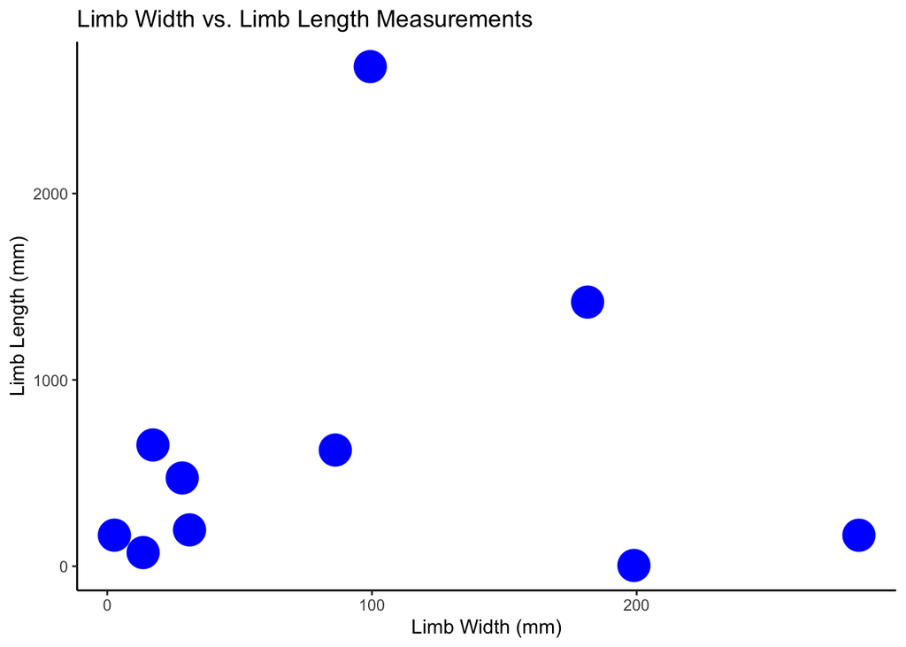

```r
qplot(x=MData$lbw, y=MData$lbl, data=MData,
      xlab="Limb Width (mm)", ylab="Limb Length (mm)", main="Limb Width vs. Limb Length Measurements",
      size=I(8), colour=I("blue")
      )+theme_classic()
```

## Plotting Width vs Length

#### For Values that Also Have Above Average Volumes

I have now made a graph that depicts all limb width and length values against each other, now to plot only for species that have an above-average volume. First, I need to calculate what the average volume is, using the mean() function. Then, I will make a new object called “AvgMData”, which only pulls out the ID#s that are larger than the average value (in this case, my average was 7235810). Then, I will just re-use the qplot() function I used in the previous step, and just replace the “data” I use with the new object I just created, “AvgMData”.

```r
mean(MData$volume)
```

```
## [1] 7235810
```

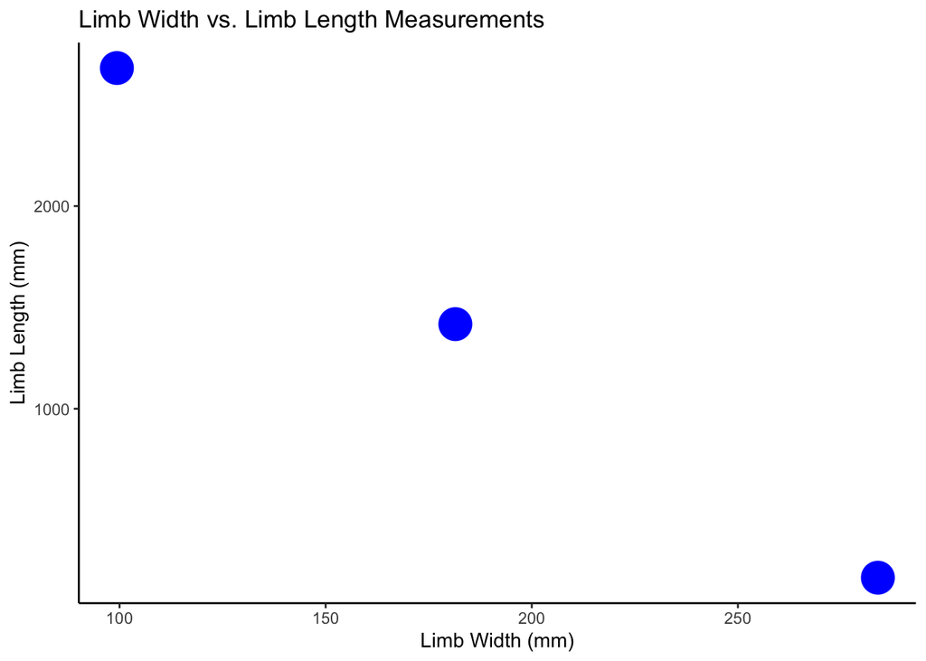

```r
AvgMData = filter(MData, MData$volume > 7235810)
qplot(x=AvgMData$lbw, y=AvgMData$lbl, data=AvgMData,
      xlab="Limb Width (mm)", ylab="Limb Length (mm)", main="Limb Width vs. Limb Length Measurements",
      size=I(8), colour=I("blue")
      )+theme_classic()
```

## Making a Table

#### Only with Species that have Below Average Volumes

Now I have to make a table that only shows the Species and Volume columns, for ID#s that are below average volume. I’ll first start by making a new object, “LowMData”, which only pulls out the ID#s with volume values below the average.

```r
LowMData = filter(MData, MData$volume < 7235810)
SelectLowMData = select(LowMData, sps, volume)

#Making sure it worked
print(SelectLowMData)
```

```
##                         sps       volume
## 1              Homo sapiens   10596.4556
## 2       Physaria chambersii  148079.9674
## 3 Thelypodium integrifolium  298619.4582
## 4    Matthiola chorassanica  132005.9850
## 5            Erysimum canum  152353.6847
## 6         Cochlearia danica     953.3742
## 7      Cardamine asarifolia 3634826.3639
```

## Adding a New “Imaginary” Group Column

Now I am going to group the species into 2 more “imaginary” categories, so first I need to add a new column with these categories, I am going with “Invasiveness” with “Native” and “Invasive” being my two categories.

```r
MData$Invasiveness = c("NATIVE", "INVASIVE")

#Making sure it worked
head(MData)
```

```
##   ID#                       sps       lbw unw         lbl unl      volume
## 1   1              Homo sapiens  13.56160  mm   73.358216  mm    10596.46
## 2   2       Physaria chambersii  31.08214  mm  195.157266  mm   148079.97
## 3   3            Rorippa anceps  99.35879  mm 2681.088337  mm 20788040.76
## 4   4       Sisymbrium loeselii 181.45842  mm 1417.501680  mm 36657911.15
## 5   5 Thelypodium integrifolium  28.32750  mm  473.818121  mm   298619.46
## 6   6    Matthiola chorassanica 198.95763  mm    4.246025  mm   132005.98
##   Invasiveness
## 1       NATIVE
## 2     INVASIVE
## 3       NATIVE
## 4     INVASIVE
## 5       NATIVE
## 6     INVASIVE
```

## Creating Tables Using These New Groups

Now that I’ve added a new category “Invasiveness” with the two groups “NATIVE” and “INVASIVE”, I am going to find the mean and SD of Length, Width, and Volume for each separate group. If I were to knit this all as one table, it will cut off my mean and SD values for volume, so for that reason I have divided my values into three separate tables, one for width, one for length, and one for volume.

#### Table for Width

```r
GrpMData = group_by(MData, Invasiveness)
print(summarise(GrpMData, MeanLimbWidth = mean(lbw), SDLimbWidth = sd(lbw)))
```

```
## # A tibble: 2 x 3
##   Invasiveness MeanLimbWidth SDLimbWidth
##   <chr>                <dbl>       <dbl>
## 1 INVASIVE             156.         99.2
## 2 NATIVE                32.2        38.6
```

#### Table for Length

```r
GrpMData = group_by(MData, Invasiveness)
print(summarise(GrpMData,MeanLimbLength = mean(lbl), SDLimbLength = sd(lbl)))
```

```
## # A tibble: 2 x 3
##   Invasiveness MeanLimbLength SDLimbLength
##   <chr>                 <dbl>        <dbl>
## 1 INVASIVE               481.         571.
## 2 NATIVE                 809.        1072.
```

#### Table for Volume

```r
GrpMData = group_by(MData, Invasiveness)
print(summarise(GrpMData,MeanLimbVolume = mean(volume), SDLimbVolume = sd(volume)))
```

```
## # A tibble: 2 x 3
##   Invasiveness MeanLimbVolume SDLimbVolume
##   <chr>                 <dbl>        <dbl>
## 1 INVASIVE          10221506.    15375613.
## 2 NATIVE             4250113.     9245781.
```